# Project_4_Premani

### Random Forest Classifier

```python
rf = RandomForestClassifier(random_state=1)
rf.fit(X_train,y_train)
```

```
RandomForestClassifier(random_state=1)
```

|  | Train Accuracy | Train Recall | Train Precision | Train F1 | Test Accuracy | Test Recall | Test Precision | Test F1 |
| --- | --- | --- | --- | --- | --- | --- | --- | --- |
| 0 | 1.0 | 1.0 | 1.0 | 1.0 | 0.920191 | 0.623188 | 0.92973 | 0.746204 |

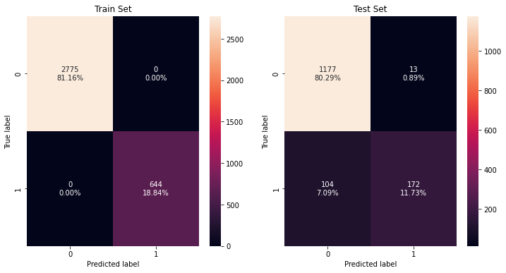

```python
# check tuned RF model performance on test set
confusion_matrix_sklearn(rf, X_train, y_train, X_test, y_test)
rf_perf = model_performance_classification_sklearn(rf, X_train, y_train, X_test, y_test)
rf_perf
```

```python
rf_tuned = RandomForestClassifier(class_weight={0:0.18,1:0.82},random_state=1,bootstrap=True)

parameters = {
                'max_depth': list(np.arange(5,20,5)) + [None],
                'max_features': ['sqrt','log2',None],
                'min_samples_leaf': np.arange(1,15,5),
                'min_samples_split': np.arange(2, 20, 5),
                'n_estimators': np.arange(10,110,10)
}


# Type of scoring used to compare parameter combinations
scorer = metrics.make_scorer(metrics.recall_score)

# Run the grid search
grid_obj = GridSearchCV(rf_tuned, parameters, scoring=scorer, cv=5,n_jobs=-1)
grid_obj = grid_obj.fit(X_train, y_train)

# Set the clf to the best combination of parameters
rf_tuned = grid_obj.best_estimator_

# Fit the best algorithm to the data.
rf_tuned.fit(X_train, y_train)
```

```
RandomForestClassifier(class_weight={0: 0.18, 1: 0.82}, max_depth=5,
                       max_features='log2', min_samples_leaf=6, n_estimators=10,
                       random_state=1)
```

|  | Train Accuracy | Train Recall | Train Precision | Train F1 | Test Accuracy | Test Recall | Test Precision | Test F1 |
| --- | --- | --- | --- | --- | --- | --- | --- | --- |
| 0 | 0.792629 | 0.734472 | 0.467854 | 0.571601 | 0.782401 | 0.702899 | 0.450116 | 0.548798 |

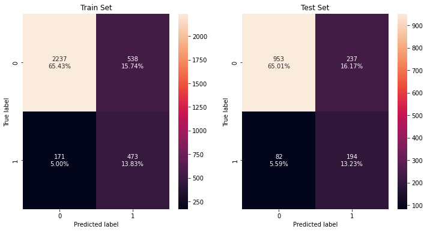

```python
# check tuned RF model performance on test set
confusion_matrix_sklearn(rf_tuned, X_train, y_train, X_test, y_test)
tuned_rf_perf = model_performance_classification_sklearn(rf_tuned, X_train, y_train, X_test, y_test)
tuned_rf_perf
```

Tuning the default Random Forest model has largely reduced overfitting, but now the tuned Random Forest Model is underfitting the data because the Test Precission and F1 Scores are very low - 45% and 55% respectively on the test data. Recall has increased from 62% to 70% on the test data, which is favorable.

### Bagging Classifier

```python
bagging_estimator = BaggingClassifier(random_state=1)
bagging_estimator.fit(X_train,y_train)
```

```
BaggingClassifier(random_state=1)
```

|  | Train Accuracy | Train Recall | Train Precision | Train F1 | Test Accuracy | Test Recall | Test Precision | Test F1 |
| --- | --- | --- | --- | --- | --- | --- | --- | --- |
| 0 | 0.993858 | 0.967391 | 1.0 | 0.983425 | 0.912005 | 0.619565 | 0.876923 | 0.726115 |

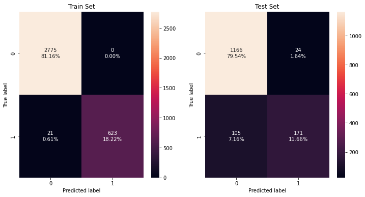

```python
# check bagging model performance on test set
confusion_matrix_sklearn(bagging_estimator, X_train, y_train, X_test, y_test)
bagging_perf = model_performance_classification_sklearn(bagging_estimator, X_train, y_train, X_test, y_test)
bagging_perf
```

#### Hyperparameter Tuning

```python
# Choose the type of classifier.
bagging_tuned = BaggingClassifier(random_state=1)

# Grid of parameters to choose from
parameters = {'max_samples': [0.7,0.8,0.9,1],
              'max_features': [0.7,0.8,0.9,1],
              'n_estimators' : [10,20,30,40,50],
             }

# Type of scoring used to compare parameter combinations
scorer = metrics.make_scorer(metrics.recall_score)

# Run the grid search
grid_obj = GridSearchCV(bagging_tuned, parameters, scoring=scorer,cv=5)
grid_obj = grid_obj.fit(X_train, y_train)

# Set the clf to the best combination of parameters
bagging_tuned = grid_obj.best_estimator_

# Fit the best algorithm to the data.
bagging_tuned.fit(X_train, y_train)
```

```
BaggingClassifier(max_features=0.9, max_samples=0.9, n_estimators=50,
                  random_state=1)
```

|  | Train Accuracy | Train Recall | Train Precision | Train F1 | Test Accuracy | Test Recall | Test Precision | Test F1 |
| --- | --- | --- | --- | --- | --- | --- | --- | --- |
| 0 | 0.999123 | 0.995342 | 1.0 | 0.997665 | 0.924284 | 0.652174 | 0.923077 | 0.764331 |

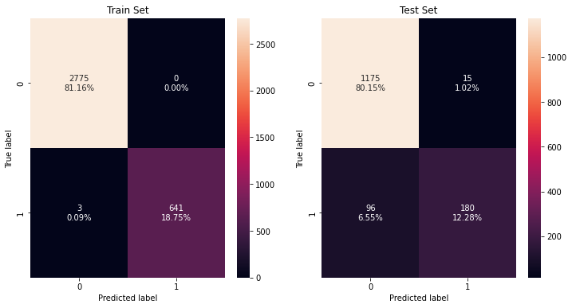

```python
# check tuned bagging model performance on test set
confusion_matrix_sklearn(bagging_tuned, X_train, y_train, X_test, y_test)
tuned_bagging_perf = model_performance_classification_sklearn(bagging_tuned, X_train, y_train, X_test, y_test)
tuned_bagging_perf
```

Tuning the Bagging Classifier model increased metrics on the test data, but model is still overfitting the training data.

### AdaBoost Classifier

```python
abc = AdaBoostClassifier(random_state=1)
abc.fit(X_train,y_train)
print(abc)
```

```
AdaBoostClassifier(random_state=1)
```

|  | Train Accuracy | Train Recall | Train Precision | Train F1 | Test Accuracy | Test Recall | Test Precision | Test F1 |
| --- | --- | --- | --- | --- | --- | --- | --- | --- |
| 0 | 0.844106 | 0.335404 | 0.672897 | 0.447668 | 0.845157 | 0.326087 | 0.687023 | 0.44226 |

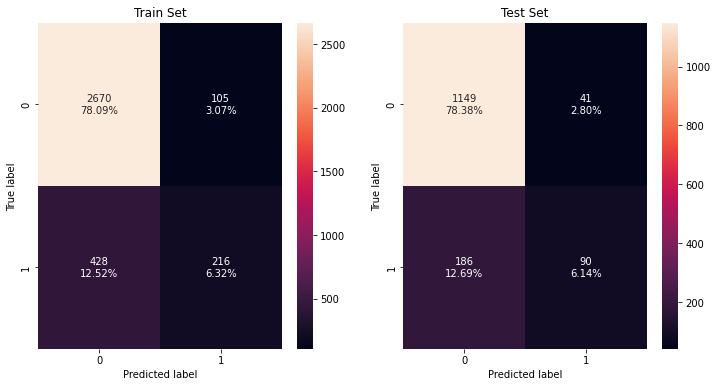

```python
# check AdaBoost model performance on test set
confusion_matrix_sklearn(abc, X_train, y_train, X_test, y_test)
abc_perf = model_performance_classification_sklearn(abc, X_train, y_train, X_test, y_test)
abc_perf
```